# A Point We Can’t Pass(e) - Reimagining UDA’s Judging Rubric

Seira Ramchandani & Sophia Rabbanian

2026-04-23

# The Big Idea:

UDA’s judging panel is evaluating an increasingly diverse global repertoire of dance, but the rubric hasn’t kept pace. Patty Adams and her panel need data-backed context on what distinguishes dance styles so judging stays credible and fair. This will lead to higher viewing rates, a wider respect and appreciation of the art of dance, and allow UDA to flourish.

## Current UDA Dance Rubric:

[figure not shown]

## Music Tempo & Learning Difficulty

[interactive chart not shown]

#### Takeaways:

- Important for judges to know that there is seemingly no correlation between learning difficulty and music pace
- Music pace should not be factored into the real or perceptual scoring rubrics.
- There are many other factors that contribute to whether a dance is difficult to learn or not.

## Common Descriptions for Dances of Different Learning Difficulties

[interactive chart not shown]

#### Takeaway:

- Many of the description terms are similar across different learning patterns
- There are some words which give us clues into patterns across difficulties:
  - “form” in the Moderate category
  - “fast” in the Easy category
  - The ordering of the terms also differs
- Please note: The “Very easy” and “Very hard” categories have less data, and therefore less words describing them, which explains the lack of insights from the bar charts.

## Tempo Patterns Differ by Continent and Century

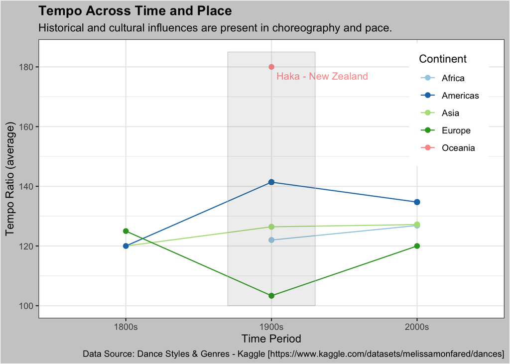

#### Takeaway:

- This context equips judges to recognize cultural and historical influences.
- Can give more depth to a piece, rather than judging dances against a single tempo standard (ex. faster=better).

## Music Genre Predicts Formation Patterns

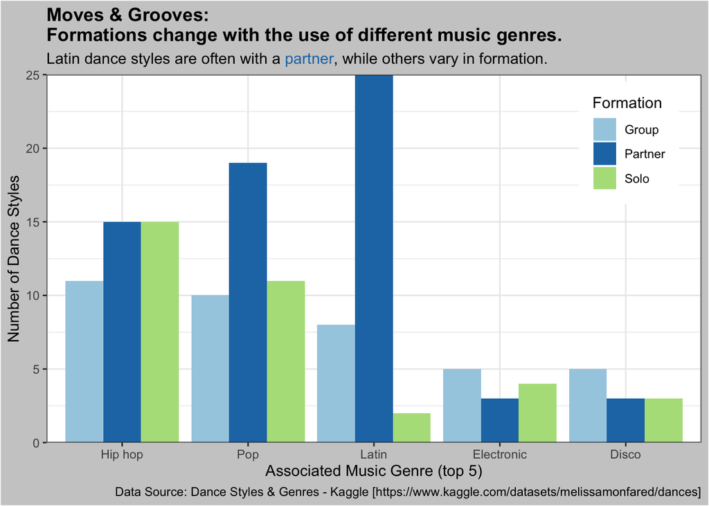

#### Takeaway:

- Judges can use genre as a lens
- Identify formations that are typical vs. innovative
- Reward intentional departures if executed well

## Where Dance Comes From

[interactive chart not shown]

#### Takeaway:

- Cultural literacy reduces unconscious bias in judging.
- Increases the panel’s credibility with international competitors.

# Conclusion & Takeaway Actions

Based on our analysis, we’re proposing four additions to the existing UDA choreography rubric, not replacements, but expansions that make the existing categories more equitable and creates more holistic criteria for judging dances.

| Current Category | Proposed Addition |
| --- | --- |
| Musical Interpretation | Add a sub-criterion: does the performance reflect the rhythmic customs of its style’s origin? |
| Routine Staging | Clarify that formation standards should be evaluated relative to genre norms. |
| Difficulty of Technical Elements | Explicitly state that tempo is not a proxy for difficulty. |
| (new) Cultural Authenticity | A new 5-point criterion rewarding demonstrated knowledge of the historical and cultural roots of the performed style. |

## Future Work:

- Adding more accurate data to represent the diversity of dance
- Get better understanding of what training judges already receive so we can identify any gaps